# Part II - Ford GoBike (San Francisco)

## by Ruth Jepngetich Kibor

## Investigation Overview

> The presentation will showcase information concerning Ford GoBike in the month of February 2019. From the data, the key insights are:
> - A large number of subscribers are male at 119,000.
> - From this faceted scatter plot, we can clearly see that the gender 'Other' has a young population of ridrs with a majority between 20 and 60. The outlier with 140 years of age is a female. We can also see that a lot more males ride longer durations compared to the other genders.
> - A majority of the riders are male,followed by females and then other.

## Dataset Overview

The dataset obtained from https://github.com/BetaNYC/Bike-Share-Data-Best-Practices/wiki/Bike-Share-Data-Systems had 183,412 rows and 16 columns before feature engineering and adding some columns such as day and month and dropping some columns and rows. The dataset now has 174,952 rows and 18 columns.The data has columns such as:

- Start date and time - "start_date: start date of trip with date and time"
- Start station location - "start_station: station id of start station"
- End date and time - "end_date: end date of trip with date and time"
- End station location - "end_station_id: station id of end station"
- Bike number - "bike_nr: id of bicycle used"
- Membership type - "subscription_type: (should be cognizant of varying membership types)"
- age of member (of registered user) - "birth_date: birth year of user"
- gender of member (of registered user) - "gender: gender of user"

## (Visualization 1)

The below visualization is a bar plot depicting the distribution of gender in the data. I wanted to know which gender had the highest number of rides. From the graph, males had the highest number of rides.

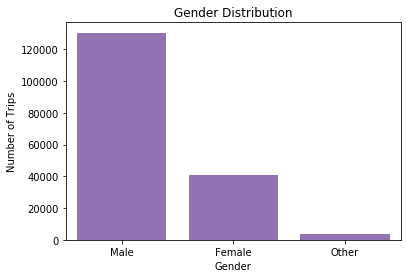

## (Visualization 2)

> With the heatmap below, wanted to explore the relationship between the gender of a user and whether they were a subscriber or a customer. From the heatmap, a majority of subscribers are males at 119,000.

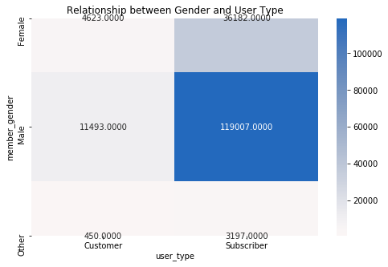

## (Visualization 3)

I created a faceted plot with three of my areas of interest; gender, duration and age. I used a faceted scatter plot. From this faceted scatter plot, we can clearly see that the gender 'Other' has a young population of ridrs with a majority between 20 and 60. The outlier with 140 years of age is a female. We can also see that a lot more males ride longer durations compared to the other genders.

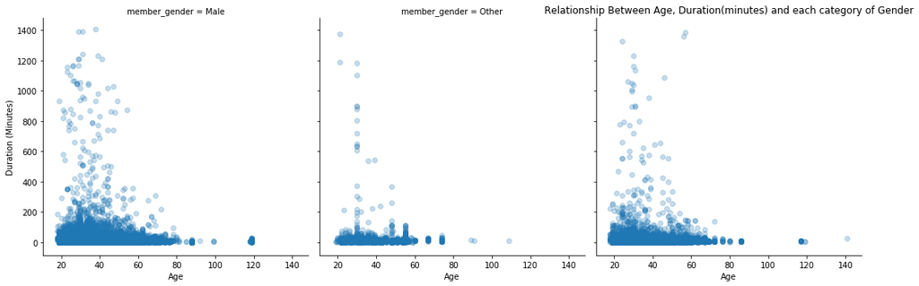